# Univariate distribution checks

This section reports a series of univariate summary checks of the NHANES dataset.

## Data set overview

Using the [Hmisc](https://cran.r-project.org/web/packages/Hmisc/) describe function, we provide an overview of the data set. The descriptive report also provides histograms of continuous variables. For ease of scanning the information, we group the report by measurement type.

### Demographic and lifestyle variables

Demographic and lifestyle variables  
6 Variables 6680 Observations

age years

| n | missing | distinct | Info | Mean | Gmd | .05 | .10 | .25 | .50 | .75 | .90 | .95 |
| --- | --- | --- | --- | --- | --- | --- | --- | --- | --- | --- | --- | --- |
| 6680 | 0 | 660 | 1 | 54.55 | 17.7 | 32.08 | 34.33 | 41.33 | 53.17 | 67.00 | 76.42 | 80.83 |

lowest : 30.00000 30.08333 30.16667 30.25000 30.33333 , highest: 84.58333 84.66667 84.75000 84.83333 84.91667

gender

| n | missing | distinct |
| --- | --- | --- |
| 6680 | 0 | 2 |

```
 Value        Male Female
 Frequency    3294   3386
 Proportion  0.493  0.507
```

educationadult

| n | missing | distinct |
| --- | --- | --- |
| 6673 | 7 | 3 |

```
 Value      Less than high school           High school More than high school
 Frequency                   1899                  1634                  3140
 Proportion                 0.285                 0.245                 0.471
```

bmi

| n | missing | distinct | Info | Mean | Gmd | .05 | .10 | .25 | .50 | .75 | .90 | .95 |
| --- | --- | --- | --- | --- | --- | --- | --- | --- | --- | --- | --- | --- |
| 6624 | 56 | 2252 | 1 | 29.07 | 6.841 | 20.69 | 22.06 | 24.72 | 28.10 | 32.25 | 37.11 | 40.80 |

lowest : 13.36 14.65 14.70 15.91 15.92 , highest: 62.77 63.42 63.87 72.28 130.21

smokecigs

| n | missing | distinct |
| --- | --- | --- |
| 6676 | 4 | 3 |

```
 Value        Never  Former Current
 Frequency     3253    1944    1479
 Proportion   0.487   0.291   0.222
```

drinkstatus

| n | missing | distinct |
| --- | --- | --- |
| 6214 | 466 | 3 |

```
 Value      Moderate Drinker      Non-Drinker    Heavy Drinker
 Frequency              3449             2336              429
 Proportion            0.555            0.376            0.069
```

### Physical activity variables

mobilityproblem

| n | missing | distinct |
| --- | --- | --- |
| 6680 | 0 | 2 |

```
 Value       No Difficulty Any Difficulty
 Frequency            5137           1543
 Proportion          0.769          0.231
```

tac

| n | missing | distinct | Info | Mean | Gmd | .05 | .10 | .25 | .50 | .75 | .90 | .95 |
| --- | --- | --- | --- | --- | --- | --- | --- | --- | --- | --- | --- | --- |
| 5972 | 708 | 5965 | 1 | 244811 | 143738 | 69233 | 94872 | 150571 | 223572 | 314224 | 417410 | 486450 |

| lowest : | 8263.000 | 8931.833 | 12123.000 | 14642.000 | 15656.000 |
| --- | --- | --- | --- | --- | --- |
| highest: | 981517.167 | 986261.000 | 986593.800 | 1097823.500 | 1122542.600 |

tlac

| n | missing | distinct | Info | Mean | Gmd | .05 | .10 | .25 | .50 | .75 | .90 | .95 |
| --- | --- | --- | --- | --- | --- | --- | --- | --- | --- | --- | --- | --- |
| 5972 | 708 | 5969 | 1 | 2900 | 873.5 | 1613 | 1900 | 2385 | 2911 | 3431 | 3877 | 4164 |

| lowest : | 313.0835 | 364.4561 | 400.8157 | 429.9288 | 466.0362 |
| --- | --- | --- | --- | --- | --- |
| highest: | 5436.1548 | 5492.5395 | 5588.3401 | 5655.4680 | 6122.6779 |

mvpa: Moderate or vigorous physical activity minutes

| n | missing | distinct | Info | Mean | Gmd | .05 | .10 | .25 | .50 | .75 | .90 | .95 |
| --- | --- | --- | --- | --- | --- | --- | --- | --- | --- | --- | --- | --- |
| 5972 | 708 | 1163 | 1 | 19.19 | 20.9 | 0.800 | 1.429 | 4.000 | 12.000 | 26.762 | 46.000 | 59.921 |

| lowest : | 0.0000000 | 0.1428571 | 0.1666667 | 0.2000000 | 0.2500000 |
| --- | --- | --- | --- | --- | --- |
| highest: | 180.8333333 | 186.2000000 | 194.8000000 | 208.5000000 | 249.0000000 |

wt

| n | missing | distinct | Info | Mean | Gmd | .05 | .10 | .25 | .50 | .75 | .90 | .95 |
| --- | --- | --- | --- | --- | --- | --- | --- | --- | --- | --- | --- | --- |
| 5972 | 708 | 3613 | 1 | 866.1 | 139.8 | 684.3 | 721.0 | 782.9 | 852.1 | 922.0 | 1000.6 | 1111.5 |

lowest : 600.000 601.500 602.000 603.000 604.000 , highest: 1425.286 1426.250 1426.286 1426.857 1440.000

satp

```
        n  missing distinct     Info     Mean      Gmd      .05      .10      .25
     5972      708     5968        1  0.08586   0.0266  0.04878  0.05711  0.07044
      .50      .75      .90      .95
  0.08447  0.10063  0.11625  0.12606
```

| lowest : | 0.007027407 | 0.007614453 | 0.007762879 | 0.007834758 | 0.008782162 |
| --- | --- | --- | --- | --- | --- |
| highest: | 0.182537744 | 0.183335690 | 0.186239620 | 0.197494834 | 0.199420122 |

astp

```
        n  missing distinct     Info     Mean      Gmd      .05      .10      .25
     5972      708     5965        1   0.2883  0.09705   0.1617   0.1860   0.2293
      .50      .75      .90      .95
   0.2796   0.3332   0.3978   0.4530
```

| lowest : | 0.03786506 | 0.03864670 | 0.05228024 | 0.05856253 | 0.05995131 |
| --- | --- | --- | --- | --- | --- |
| highest: | 0.75000000 | 0.76086957 | 0.79487179 | 0.80000000 | 0.93333333 |

### Physiological measurements

Physiological measurements  
3 Variables 6680 Observations

sys: Systolic blood pressure mg/dl

| n | missing | distinct | Info | Mean | Gmd | .05 | .10 | .25 | .50 | .75 | .90 | .95 |
| --- | --- | --- | --- | --- | --- | --- | --- | --- | --- | --- | --- | --- |
| 6360 | 320 | 139 | 1 | 127.3 | 22.17 | 100 | 105 | 113 | 124 | 138 | 154 | 166 |

lowest : 73 80 81 82 83 , highest: 228 230 238 256 270

lbxtc

| n | missing | distinct | Info | Mean | Gmd | .05 | .10 | .25 | .50 | .75 | .90 | .95 |
| --- | --- | --- | --- | --- | --- | --- | --- | --- | --- | --- | --- | --- |
| 6410 | 270 | 268 | 1 | 203.9 | 46.64 | 142 | 154 | 175 | 201 | 229 | 258 | 277 |

lowest : 82 83 85 92 94 , highest: 441 458 539 650 704

lbdhdd

| n | missing | distinct | Info | Mean | Gmd | .05 | .10 | .25 | .50 | .75 | .90 | .95 |
| --- | --- | --- | --- | --- | --- | --- | --- | --- | --- | --- | --- | --- |
| 6410 | 270 | 113 | 1 | 54.56 | 17.99 | 33 | 37 | 42 | 52 | 63 | 76 | 85 |

lowest : 17 19 21 22 23 , highest: 151 152 154 164 188

### Comorbidities

Comorbidities  
5 Variables 6680 Observations

mortstat

| n | missing | distinct |
| --- | --- | --- |
| 6671 | 9 | 2 |

```
 Value      alive  dead
 Frequency   5490  1181
 Proportion 0.823 0.177
```

diabetes

| n | missing | distinct |
| --- | --- | --- |
| 6680 | 0 | 2 |

```
 Value         No   Yes
 Frequency   5828   852
 Proportion 0.872 0.128
```

chf

| n | missing | distinct |
| --- | --- | --- |
| 6680 | 0 | 2 |

```
 Value        No  Yes
 Frequency  6416  264
 Proportion 0.96 0.04
```

cancer

| n | missing | distinct |
| --- | --- | --- |
| 6680 | 0 | 2 |

```
 Value         No   Yes
 Frequency   6008   672
 Proportion 0.899 0.101
```

stroke

| n | missing | distinct |
| --- | --- | --- |
| 6680 | 0 | 2 |

```
 Value         No   Yes
 Frequency   6406   274
 Proportion 0.959 0.041
```

## Categorical variables

We now provide a closer visual examination of the categorical predictors.

[figure not shown]

## Continuous variables

A closer visual examination of continuous predictors and the outcome variable.

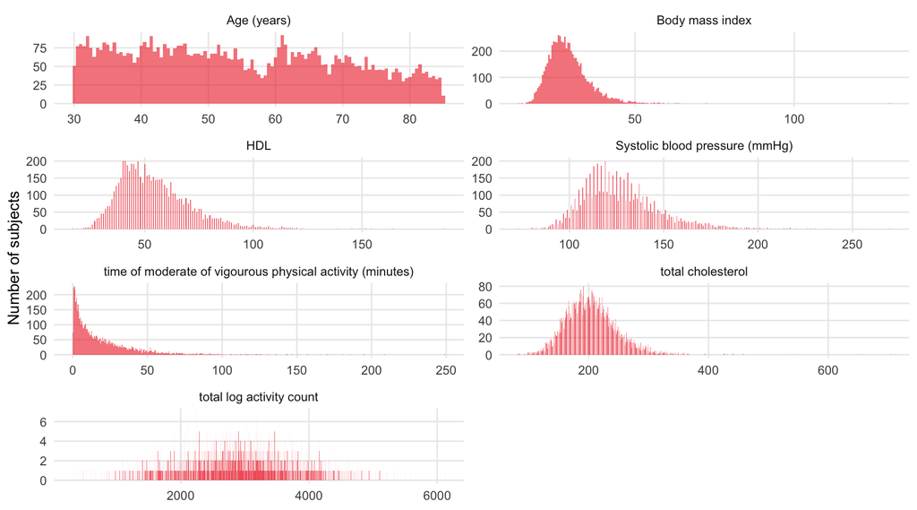

There is evidence of influential points in some of the distributions. This is explored further with targeted summaries. A more detailed univariate summaries for the variables of interest are also provided below.

### Outcome= Time of moderate or vigrous physical activity

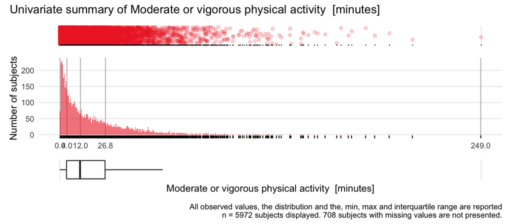

Distribution of time of moderate/vigorous activity [minutes]

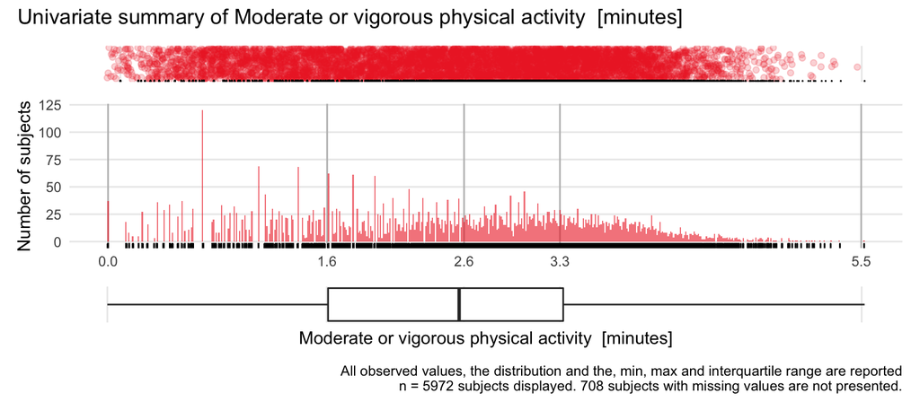

Distribution of log(1+MVPA)

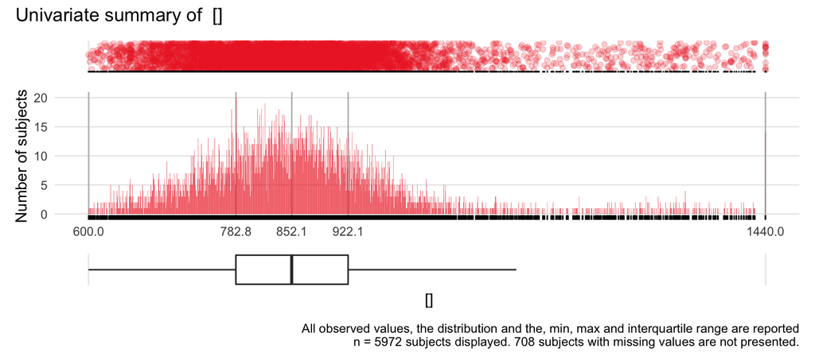

Distribution of wear time [minutes]

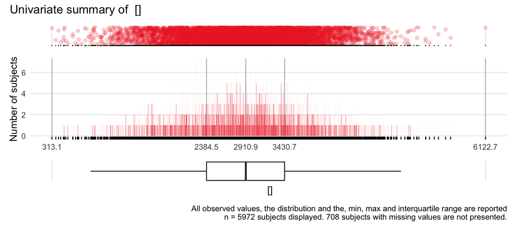

Distribution of log total activity count

### Blood pressure

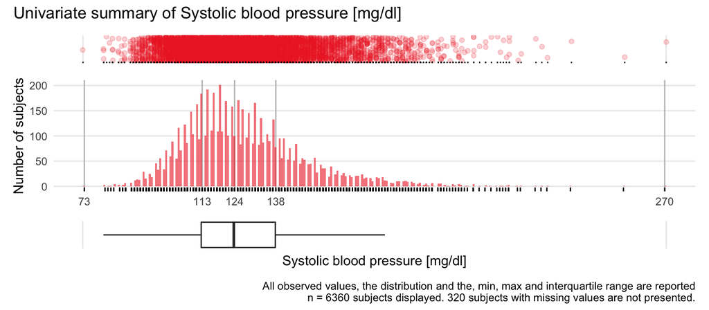

Distribution of SBP

### Body mass index

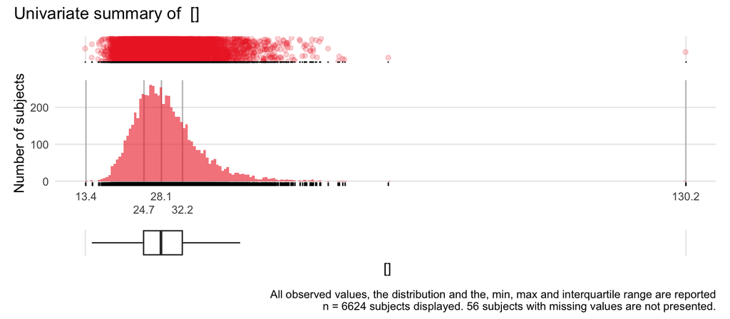

There is a participant with an unusal high value (130.2). It is possible that this is an entry error (bmi=30.2).

### Total cholesterol

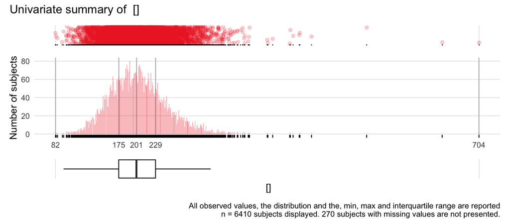

Distribution of total cholesterol

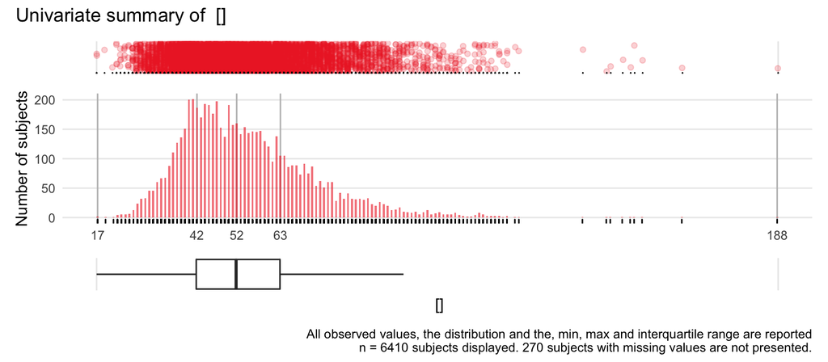

Distribution of HDL